# Построение оптимального по Марковитцу портфеля

Считываем импортированные данные

```r
data <- read.csv('myData.csv',header = TRUE)
head(data)
```

```
##                        Date   CZR        D      DAL       DD       DE      DFS
## 1 2022-01-03 00:00:00-05:00 93.47 70.67307 39.99815 77.10395 339.9776 112.2874
## 2 2022-01-04 00:00:00-05:00 89.95 70.44757 40.29598 78.90105 360.5447 115.7515
## 3 2022-01-05 00:00:00-05:00 84.15 71.44881 39.98822 78.18412 361.2827 114.1804
## 4 2022-01-06 00:00:00-05:00 86.60 71.31350 39.81946 78.37531 365.4679 116.2436
## 5 2022-01-07 00:00:00-05:00 89.66 72.35082 41.20931 79.52241 367.6917 118.9600
## 6 2022-01-10 00:00:00-05:00 88.30 72.00806 40.33569 78.35619 368.8667 120.6920
##         DG      DGX       DHI      DHR
## 1 228.7296 156.1990 102.64796 277.3124
## 2 227.0005 150.3540 103.09654 269.8474
## 3 227.0977 149.5177 100.51230 268.1261
## 4 229.0404 150.4870  98.98126 266.9141
## 5 231.4396 148.1395  92.87661 259.6686
## 6 229.5358 151.6845  93.34470 266.1324
```

```r
tail(data)
```

```
##                          Date   CZR     D   DAL    DD     DE    DFS     DG
## 586 2024-05-02 00:00:00-04:00 35.14 51.16 51.03 77.75 395.96 124.51 137.15
## 587 2024-05-03 00:00:00-04:00 35.33 51.40 51.55 77.67 400.96 125.04 137.49
## 588 2024-05-06 00:00:00-04:00 36.05 51.41 52.93 78.53 401.84 125.36 136.14
## 589 2024-05-07 00:00:00-04:00 36.35 52.12 52.20 79.29 405.57 123.61 139.90
## 590 2024-05-08 00:00:00-04:00 36.22 52.15 52.28 78.20 405.42 123.57 137.52
## 591 2024-05-09 00:00:00-04:00 37.30 52.84 52.75 78.80 409.00 124.04 140.86
##        DGX    DHI    DHR
## 586 136.34 145.46 246.84
## 587 137.38 148.48 248.38
## 588 135.64 151.26 247.40
## 589 136.94 151.40 248.76
## 590 136.14 147.74 249.55
## 591 138.16 149.50 251.43
```

```r
(nAsset <- dim(data)[2])
```

```
## [1] 11
```

```r
(nDays <- dim(data)[1])
```

```
## [1] 591
```

Переводим первый столбец из строки в переменную типа Date

```r
Dates <- data[,1]
Dates <- as.Date(Dates, "%Y-%m-%d")
head(Dates)
```

```
## [1] "2022-01-03" "2022-01-04" "2022-01-05" "2022-01-06" "2022-01-07"
## [6] "2022-01-10"
```

Убираем первый столбец c датами остальные переводим в тип xts( time series).

```r
library(xts)
```

```r
histData <- data[2:nAsset]
sample.xts <- as.xts(histData, order.by = Dates)
head(sample.xts)
```

```
##              CZR        D      DAL       DD       DE      DFS       DG      DGX
## 2022-01-03 93.47 70.67307 39.99815 77.10395 339.9776 112.2874 228.7296 156.1990
## 2022-01-04 89.95 70.44757 40.29598 78.90105 360.5447 115.7515 227.0005 150.3540
## 2022-01-05 84.15 71.44881 39.98822 78.18412 361.2827 114.1804 227.0977 149.5177
## 2022-01-06 86.60 71.31350 39.81946 78.37531 365.4679 116.2436 229.0404 150.4870
## 2022-01-07 89.66 72.35082 41.20931 79.52241 367.6917 118.9600 231.4396 148.1395
## 2022-01-10 88.30 72.00806 40.33569 78.35619 368.8667 120.6920 229.5358 151.6845
##                  DHI      DHR
## 2022-01-03 102.64796 277.3124
## 2022-01-04 103.09654 269.8474
## 2022-01-05 100.51230 268.1261
## 2022-01-06  98.98126 266.9141
## 2022-01-07  92.87661 259.6686
## 2022-01-10  93.34470 266.1324
```

Выделим 5 последних дат на проверку результата, а первые nDays-5 оставим на построение портфеля

```r
Lag <- 5
(testData <- sample.xts[(nDays-Lag):nDays,])
```

```
##              CZR     D   DAL    DD     DE    DFS     DG    DGX    DHI    DHR
## 2024-05-02 35.14 51.16 51.03 77.75 395.96 124.51 137.15 136.34 145.46 246.84
## 2024-05-03 35.33 51.40 51.55 77.67 400.96 125.04 137.49 137.38 148.48 248.38
## 2024-05-06 36.05 51.41 52.93 78.53 401.84 125.36 136.14 135.64 151.26 247.40
## 2024-05-07 36.35 52.12 52.20 79.29 405.57 123.61 139.90 136.94 151.40 248.76
## 2024-05-08 36.22 52.15 52.28 78.20 405.42 123.57 137.52 136.14 147.74 249.55
## 2024-05-09 37.30 52.84 52.75 78.80 409.00 124.04 140.86 138.16 149.50 251.43
```

```r
sample.xts <- sample.xts[1:(nDays-Lag),]
tail(sample.xts)
```

```
##              CZR     D   DAL    DD     DE    DFS     DG    DGX      DHI    DHR
## 2024-04-25 38.04 50.97 49.88 73.50 394.06 125.67 142.65 135.42 143.8964 245.80
## 2024-04-26 36.61 50.45 49.92 73.71 393.33 127.70 142.07 134.26 145.0240 246.58
## 2024-04-29 37.57 51.14 50.45 73.90 400.96 128.00 141.15 139.50 145.6627 246.82
## 2024-04-30 35.82 50.98 50.07 72.50 391.41 126.73 139.19 138.18 142.1900 246.62
## 2024-05-01 36.38 51.15 50.02 78.31 387.50 123.58 137.58 137.55 142.4800 246.89
## 2024-05-02 35.14 51.16 51.03 77.75 395.96 124.51 137.15 136.34 145.4600 246.84
```

```r
nDays <- nDays - Lag
```

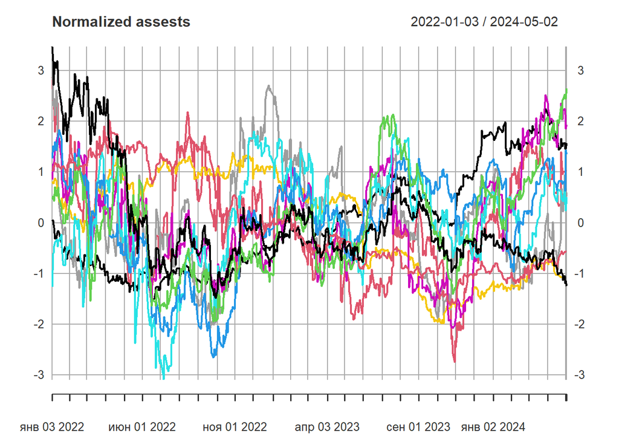

```r
std_data <- scale(sample.xts)
plot(std_data,lty=1,main='Normalized assests',type = "l")
```

```r
library(fPortfolio)
stock.returns <- returns(sample.xts,method = 'discrete')
head(stock.returns)
```

[output not shown]

Убираем первую строку

```r
stock.returns<-stock.returns[2:nDays,]
head(stock.returns)
```

```
##                    CZR            D          DAL           DD          DE
## 2022-01-04 -0.03765919 -0.003190777  0.007445965  0.023307546 0.060495385
## 2022-01-05 -0.06448022  0.014212606 -0.007637351 -0.009086497 0.002046837
## 2022-01-06  0.02911464 -0.001893872 -0.004220393  0.002445415 0.011584396
## 2022-01-07  0.03533493  0.014545956  0.034903901  0.014635919 0.006084679
## 2022-01-10 -0.01516842 -0.004737447 -0.021199647 -0.014665321 0.003195579
## 2022-01-11  0.01902605 -0.008768689  0.014767407  0.012931557 0.001816411
##                     DFS            DG          DGX          DHI          DHR
## 2022-01-04  0.030849641 -0.0075591627 -0.037420322  0.004370061 -0.026919195
## 2022-01-05 -0.013573163  0.0004279845 -0.005562334 -0.025066251 -0.006378841
## 2022-01-06  0.018070276  0.0085544150  0.006483352 -0.015232329 -0.004520169
## 2022-01-07  0.023367507  0.0104748770 -0.015599274 -0.061674829 -0.027145262
## 2022-01-10  0.014559605 -0.0082259429  0.023930128  0.005039872  0.024892517
## 2022-01-11  0.008312422 -0.0324151233 -0.010776901  0.031445762  0.007590050
```

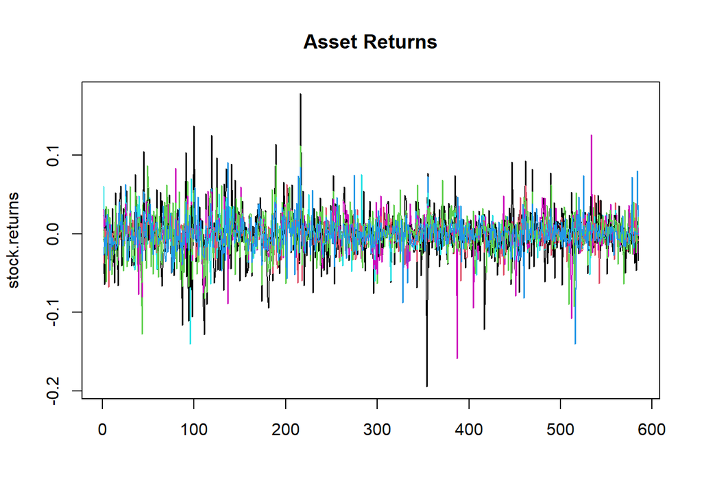

```r
matplot(stock.returns,lty=1,main='Asset Returns',type = "l")
```

Считаем ковариационную матрицу доходностей

```r
(cov <- cov(stock.returns))
```

```
##              CZR            D          DAL           DD           DE
## CZR 0.0012660600 1.135360e-04 5.201405e-04 3.749834e-04 2.605188e-04
## D   0.0001135360 2.364031e-04 6.054668e-05 7.513774e-05 6.958593e-05
## DAL 0.0005201405 6.054668e-05 5.676391e-04 2.296215e-04 1.850506e-04
## DD  0.0003749834 7.513774e-05 2.296215e-04 3.509587e-04 1.567679e-04
## DE  0.0002605188 6.958593e-05 1.850506e-04 1.567679e-04 3.571975e-04
## DFS 0.0004369451 6.122096e-05 3.091796e-04 2.091707e-04 1.650448e-04
## DG  0.0001930146 7.912022e-05 1.126019e-04 9.509389e-05 1.059302e-04
## DGX 0.0001407768 6.390684e-05 8.923815e-05 8.389963e-05 6.907281e-05
## DHI 0.0004327757 8.776841e-05 2.345003e-04 1.882492e-04 1.145159e-04
## DHR 0.0003007737 9.438653e-05 1.490504e-04 1.475037e-04 1.041410e-04
##              DFS           DG          DGX          DHI          DHR
## CZR 4.369451e-04 1.930146e-04 1.407768e-04 4.327757e-04 3.007737e-04
## D   6.122096e-05 7.912022e-05 6.390684e-05 8.776841e-05 9.438653e-05
## DAL 3.091796e-04 1.126019e-04 8.923815e-05 2.345003e-04 1.490504e-04
## DD  2.091707e-04 9.509389e-05 8.389963e-05 1.882492e-04 1.475037e-04
## DE  1.650448e-04 1.059302e-04 6.907281e-05 1.145159e-04 1.041410e-04
## DFS 5.542075e-04 9.490566e-05 8.560264e-05 2.258144e-04 1.395669e-04
## DG  9.490566e-05 4.443581e-04 7.527243e-05 1.360557e-04 8.561381e-05
## DGX 8.560264e-05 7.527243e-05 1.884222e-04 1.123398e-04 9.693764e-05
## DHI 2.258144e-04 1.360557e-04 1.123398e-04 5.204822e-04 1.905907e-04
## DHR 1.395669e-04 8.561381e-05 9.693764e-05 1.905907e-04 3.250885e-04
```

Зададим матрицу $Amat$ и вектор $bvec$ ограничений.

```r
n <- ncol(cov)
Amat <- matrix (1, nrow=n)
Amat <- cbind(Amat, -diag(n))
bvec <- 1
meq <- 1
```

```r
max.allocation <- 0.45
bvec <- c(bvec, rep(-max.allocation, n))
bvec
```

```
##  [1]  1.00 -0.45 -0.45 -0.45 -0.45 -0.45 -0.45 -0.45 -0.45 -0.45 -0.45
```

Зададим максимальную доходность и шаг изменения доходности и определим количество итераций цикла по доходности.

```r
risk.premium.up <-0.5
risk.increment <- 0.01
(loops <- risk.premium.up / risk.increment + 1)
```

```
## [1] 51
```

```r
loop <- 1
```

Инициализируем матрицу, где будем хранить оптимальные портфели и различные статистики

```r
eff <- matrix(nrow=loops, ncol=n+3)
colnames(eff) <- c(colnames(stock.returns), "Std.Dev", "Exp.Return", "sharpe")
```

Получаем оптимальный портфель, доходность, стандартное отклонение и коэффициент Шарпа на каждой итерации

```r
library(quadprog)
mu <- colMeans(stock.returns)
for (i in seq(from=0, to=risk.premium.up, by=risk.increment)){
  dvec <- mu * i
  sol <- solve.QP(cov, dvec=dvec, Amat=Amat, bvec=bvec, meq=meq)
  eff[loop,"Std.Dev"] <- sqrt(sum(sol$solution *colSums((cov * sol$solution))))
  eff[loop,"Exp.Return"] <- as.numeric(sol$solution %*% colMeans(stock.returns))
  eff[loop,"sharpe"] <- eff[loop,"Exp.Return"] / eff[loop,"Std.Dev"]
  eff[loop,1:n] <- sol$solution
  loop <- loop+1
}
eff <- as.data.frame(eff)
head(eff)
```

```
##          CZR         D        DAL         DD        DE        DFS           DG
## 1 -0.1111178 0.2491408 0.05599003 0.09849863 0.1102224 0.05387933  0.091977662
## 2 -0.1413589 0.2266599 0.07850168 0.10388037 0.1287312 0.05905756  0.073197186
## 3 -0.1715999 0.2041789 0.10101333 0.10926210 0.1472401 0.06423579  0.054416710
## 4 -0.2018410 0.1816980 0.12352498 0.11464383 0.1657489 0.06941402  0.035636235
## 5 -0.2320821 0.1592171 0.14603663 0.12002556 0.1842578 0.07459225  0.016855759
## 6 -0.2623232 0.1367362 0.16854828 0.12540729 0.2027667 0.07977048 -0.001924717
##         DGX        DHI        DHR    Std.Dev   Exp.Return      sharpe
## 1 0.3372707 0.01560227 0.09853603 0.01037026 4.234598e-05 0.004083406
## 2 0.3226552 0.04965973 0.09901603 0.01042405 1.542038e-04 0.014793074
## 3 0.3080398 0.08371720 0.09949602 0.01058379 2.660616e-04 0.025138593
## 4 0.2934243 0.11777467 0.09997602 0.01084479 3.779194e-04 0.034848009
## 5 0.2788089 0.15183213 0.10045602 0.01119998 4.897772e-04 0.043730185
## 6 0.2641934 0.18588960 0.10093601 0.01164074 6.016349e-04 0.051683584
```

Определяем точку, где коэффициент Шарпа максимален

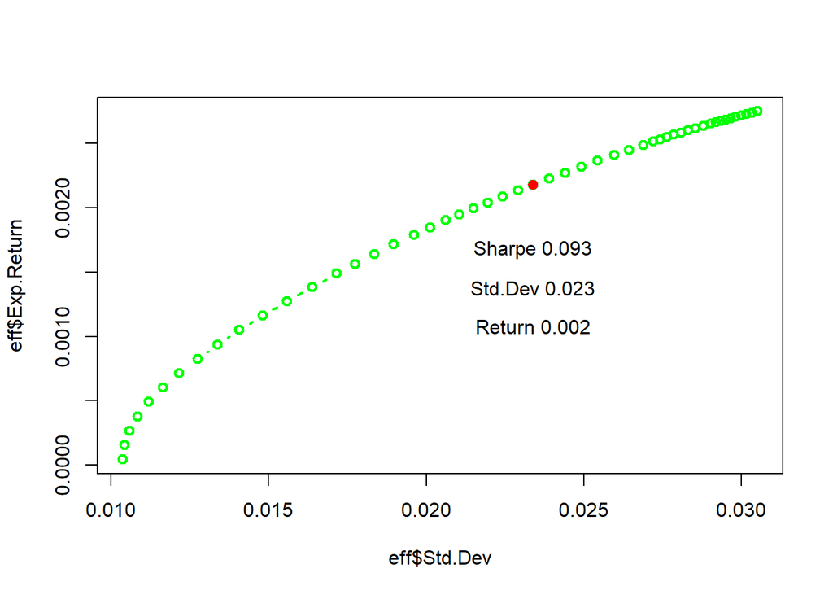

```r
eff.optimal.point <- eff[eff$sharpe==max(eff$sharpe),]

plot(eff$Std.Dev,eff$Exp.Return,type = 'b',pch =21,col = 'green',lwd = 2)
points(eff.optimal.point$Std.Dev,eff.optimal.point$Exp.Return,pch = 20,col = 'red',lwd = 4)
text(eff.optimal.point$Std.Dev,eff.optimal.point$Exp.Return-0.0005,paste('Sharpe',round(eff.optimal.point$sharpe,3)))
text(eff.optimal.point$Std.Dev,eff.optimal.point$Exp.Return-0.0008,paste('Std.Dev',round(eff.optimal.point$Std.Dev,3)))
text(eff.optimal.point$Std.Dev,eff.optimal.point$Exp.Return-0.0011,paste('Return',round(eff.optimal.point$Exp.Return,3)))
```

Оптимальный портфель по Марковитцу

```r
eff.optimal.point
```

```
##           CZR          D  DAL        DD   DE       DFS         DG       DGX
## 26 -0.7538405 -0.2638754 0.45 0.3501363 0.45 0.3022524 -0.3085143 0.1040381
##     DHI       DHR    Std.Dev  Exp.Return     sharpe
## 26 0.45 0.2198034 0.02339746 0.002179645 0.09315733
```

Предположим у Вас 1000000 долларов Разделим его на доли вложения в каждый актив. Для этого нормируем оптимальный портфель так, чтобы сумма модулей была равна 1.

```r
eff.optimal.point<-eff.optimal.point[1:10]
sabs <- sum(abs(eff.optimal.point))
norm_eff.optimal.point <- eff.optimal.point/sabs
sum(abs(norm_eff.optimal.point))
```

```
## [1] 1
```

Поделим весь капитал на долю вложения на каждый актив

```r
N <- 1000000
(d_money <- norm_eff.optimal.point*N)
```

```
##          CZR         D      DAL       DD       DE     DFS        DG      DGX
## 26 -206392.5 -72245.93 123204.6 95863.13 123204.6 82753.1 -84467.53 28484.39
##         DHI      DHR
## 26 123204.6 60179.55
```

В итоге портфель на следующий интервал времени в количестве акций на последний день тренировочной выборки

```r
nData <- dim(sample.xts)[1]
(portfolio <- as.integer (d_money/ histData[nData,]))
```

```
##  [1] -5873 -1412  2414  1232   311   664  -615   208   846   243
```

Его стоимость на момент создания с учетом округлений

```r
sum(abs(portfolio)*histData[nData,])
```

```
## [1] 999155
```

Посмотрим на стоимость нашего портфеля по тестовым 5 дням

```r
res <- rep(0,Lag)
for (i in 1 :Lag)
{
  change <- histData[nData+i,]-histData[nData,]
  res[i]<-sum(portfolio*change)
  print(paste(Dates[nData+i],' ',res[i]))
}
```

```
## [1] "2024-05-03   4545.21875762939"
## [1] "2024-05-06   7761.62991714478"
## [1] "2024-05-07   2576.27648925781"
## [1] "2024-05-08   467.323181152344"
## [1] "2024-05-09   -3238.68015670776"
```

Стоимость нашего портфеля по 5 тестовым дням

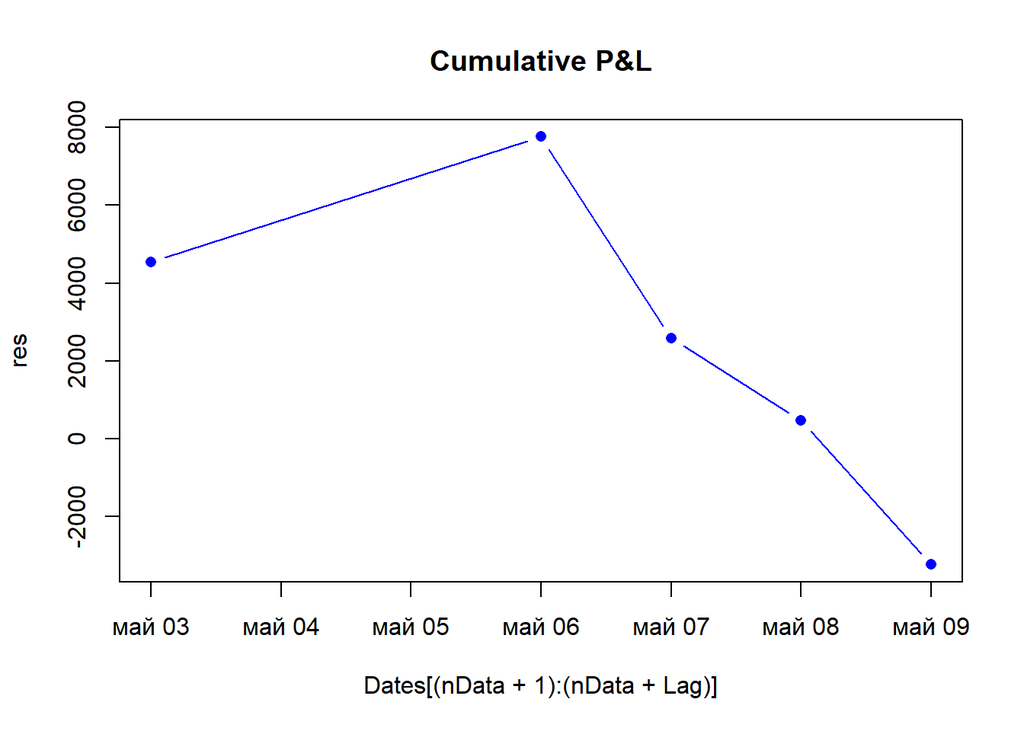

```r
plot(Dates[(nData+1):(nData+Lag)], res,main='Cumulative P&L',type="b",col = 'blue',pch=16)
```